# Figure 3. Taxonomical and functional characteristics of differential bacteria between the indica and japonica root microbiota.

Yong-Xin Liu

2019/2/20

## a-b. Manhattan plot

(a–b) Manhattan plot showing OTUs enriched in indica or japonica in field I (a) and field II (b). Each dot or triangle represents a single OTU. OTUs enriched in indica or japonica are represented by filled or empty triangles, respectively (FDR adjusted P < 0.05, Wilcoxon rank sum test). OTUs are arranged in taxonomic order and colored according to the phylum and class of Proteobacteria.

- Script for differentially abundance OTUs

### a. Plotting manhattan plot for field I

```r
library("Biobase")
library("edgeR")
```

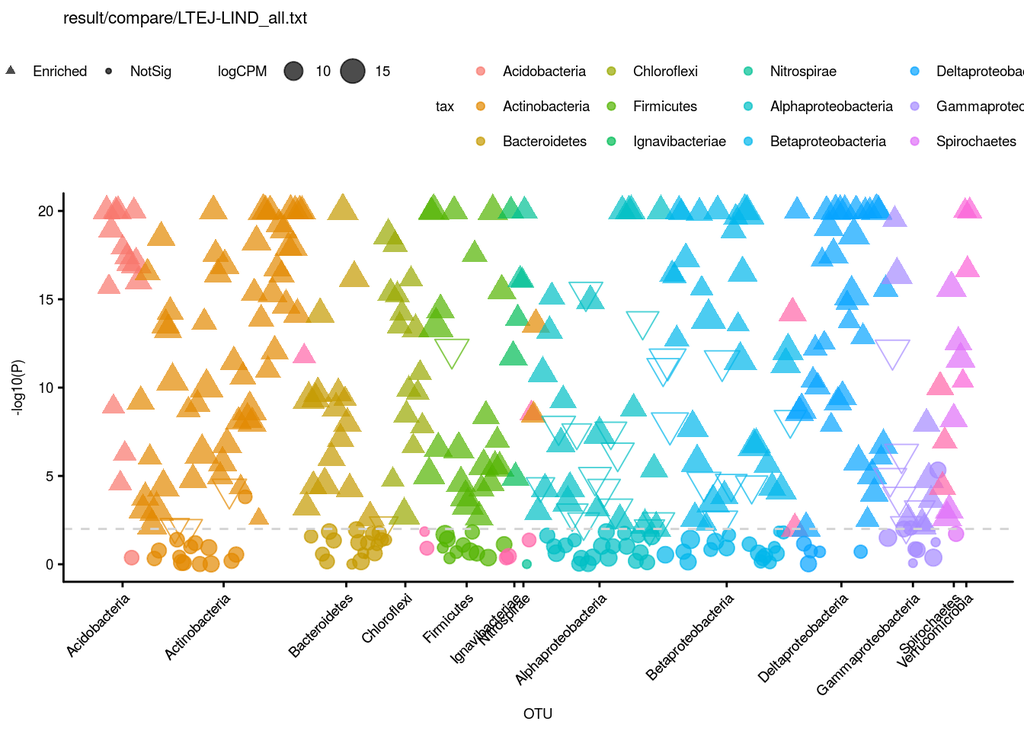

```r
library("ggplot2")
library("gplots")
library("grid")
library("RColorBrewer")
library("reshape2")
library("VennDiagram")
library("dplyr")
library("pheatmap")

# India vs Japonica in field I
x = read.table("../data/LIND-LTEJ_all.txt", header=T, row.names= 1, sep="\t", stringsAsFactors = F)
x = x[,1:14]
x = na.omit(x)

# Negtive log Pvalue for manhattan
x$neglogp = -log10(x$PValue)

x$otu=rownames(x)
x = arrange(x, Kindom, Phylum, Class, Order, Family, Genus, Species)
x$otu = factor(x$otu, levels=x$otu)   # set x order
x$num = 1:dim(x)[1]

# Color by taxonomy
per= read.delim("../data/sum_pc.txt", sep = "\t", row.names=1, header=T)
mean = rowMeans(per)
per = as.data.frame(mean[order(mean, decreasing = T)])
top_tax=head(rownames(per), n=13)

# group non-top into Low Abundance
x$tax = x$Phylum
# Proteobacteria classified into class
x[x$tax %in% "Proteobacteria",]$tax =  x[x$tax %in% "Proteobacteria",]$Class # no level can get value
if (length(unique(x$tax)) > length(top_tax)){
    x[!(x$tax %in% top_tax),]$tax = "Low Abundance"
}

# Adjust label order
label = unique(x$tax)
label = label[!(label %in% "Low Abundance")] # Delete low abundance
x$tax = factor(x$tax, levels = c(label, "Low Abundance"))
# Claculate labe median
temp = x[x$tax %in% label, c("tax","num")]
mat_mean = aggregate(temp[,-1], by=temp[1], FUN=median) # mean

# Set max neglogp
if (max(x$neglogp)>20){
  x[x$neglogp>20,]$neglogp  = 20
}

# Manhattan plot
FDR = min(x$neglogp[x$level!="NotSig"])
p = ggplot(x, aes(x=num, y=neglogp, color=tax, size=logCPM, shape=level)) +
  geom_point(alpha=.7) +
  geom_hline(yintercept=FDR, linetype=2, color="lightgrey") +
  scale_shape_manual(values=c(25, 17, 20))+
  scale_size(breaks=c(5, 10, 15)) +
  labs(x="OTU", y="-log10(P)", title=paste("result/compare/LTEJ-LIND_all.txt", sep=" ")) +main_theme +
  theme(legend.position="top") +
  scale_x_continuous(breaks=mat_mean$x, labels=mat_mean$tax) +
  theme(axis.text.x=element_text(angle=45, hjust=1, vjust=1))
ggsave(file=paste("manhattan_LTEJ-LIND.pdf", sep=""), p, width = 10, height = 4, useDingbats=F)
p
```

### b. Plotting manhattan plot for field II

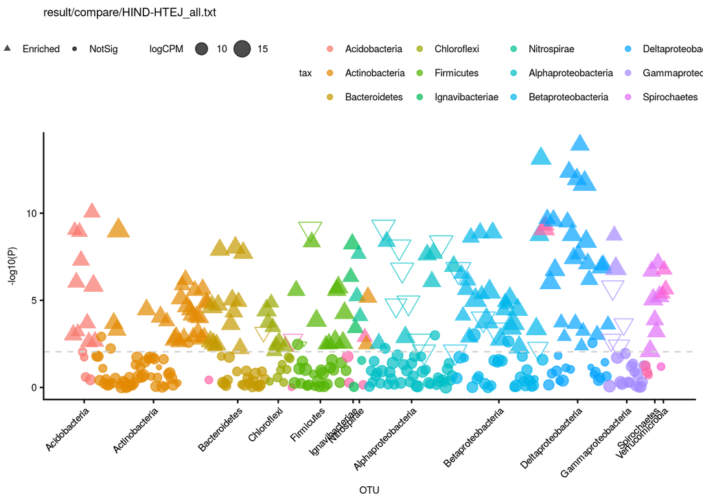

```r
# India vs Japonica in field II
x = read.table("../data/HIND-HTEJ_all.txt", header=T, row.names= 1, sep="\t", stringsAsFactors = F)
x = x[,1:14]
x = na.omit(x)

# Negtive log Pvalue for manhattan
x$neglogp = -log10(x$PValue)

x$otu=rownames(x)
x = arrange(x, Kindom, Phylum, Class, Order, Family, Genus, Species)
x$otu = factor(x$otu, levels=x$otu)   # set x order
x$num = 1:dim(x)[1]

# Color by taxonomy
per= read.delim("../data/sum_pc.txt", sep = "\t", row.names=1, header=T)
mean = rowMeans(per)
per = as.data.frame(mean[order(mean, decreasing = T)])
top_tax=head(rownames(per), n=13)

# group non-top into Low Abundance
x$tax = x$Phylum

# Proteobacteria classified into class
x[x$tax %in% "Proteobacteria",]$tax =  x[x$tax %in% "Proteobacteria",]$Class # no level can get value

if (length(unique(x$tax)) > length(top_tax)){
    x[!(x$tax %in% top_tax),]$tax = "Low Abundance" # no level can get value
}

# Adjust label order
label = unique(x$tax)
label = label[!(label %in% "Low Abundance")] # Delete low abundance
x$tax = factor(x$tax, levels = c(label, "Low Abundance"))
# Claculate labe median
temp = x[x$tax %in% label, c("tax","num")]
mat_mean = aggregate(temp[,-1], by=temp[1], FUN=median) # mean


# Set max neglogp
if (max(x$neglogp)>20){
  x[x$neglogp>20,]$neglogp  = 20
}

# Manhattan plot
FDR = min(x$neglogp[x$level!="NotSig"])
p = ggplot(x, aes(x=num, y=neglogp, color=tax, size=logCPM, shape=level)) +
  geom_point(alpha=.7) +
  geom_hline(yintercept=FDR, linetype=2, color="lightgrey") +
  scale_shape_manual(values=c(25, 17, 20))+
  scale_size(breaks=c(5, 10, 15)) +
  labs(x="OTU", y="-log10(P)", title=paste("result/compare/HIND-HTEJ_all.txt", sep=" ")) +main_theme +
  theme(legend.position="top") +
  scale_x_continuous(breaks=mat_mean$x, labels=mat_mean$tax) +
  theme(axis.text.x=element_text(angle=45, hjust=1, vjust=1))
ggsave(file=paste("manhattan_HIND-HTEJ.pdf", sep=""), p, width = 10, height = 4, useDingbats=F)
p
```

## c-d. Overlapped OTUs in filed I and filed II

(c–d) Overlapping OTUs enriched in indica (c) or japonica (d) in both fields.

### c. overlapped OTUs of indica enriched

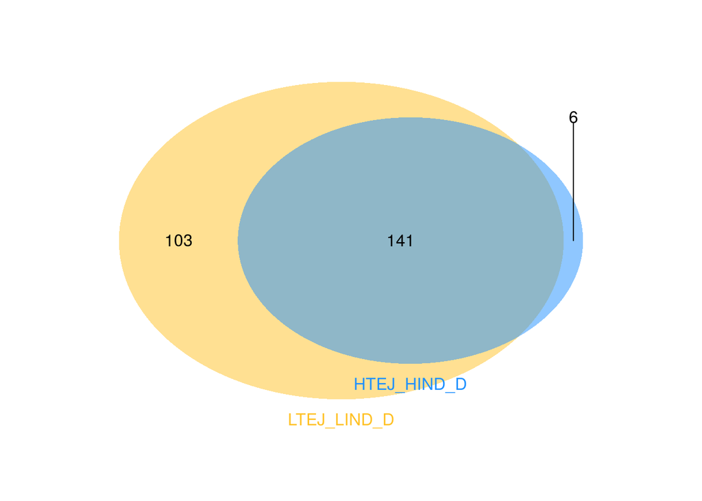

```r
library(VennDiagram)
num =2
data <- read.table(file="../data/diff.list", sep="\t", quote="")
HTEJ_HIND_D <- data[grepl("\\<HTEJ_HIND_D\\>",data[,2]),1]
LTEJ_LIND_D <- data[grepl("\\<LTEJ_LIND_D\\>",data[,2]),1]
color_v <- c("dodgerblue", "goldenrod1", "darkorange1", "seagreen3", "orchid3")[1:num]
p <- venn.diagram(
    x = list(HTEJ_HIND_D=HTEJ_HIND_D, LTEJ_LIND_D=LTEJ_LIND_D),
    filename = NULL, col = "transparent",
    fill = color_v,
    alpha = 0.50,
    label.col = c("black"),
    cex = 1, fontfamily = "Helvetica",
    cat.default.pos="outer",
    cat.pos=0, margin=0.1,
    cat.col = color_v,cat.cex = 1, cat.fontfamily = "Helvetica"
)
grid.draw(p)
```

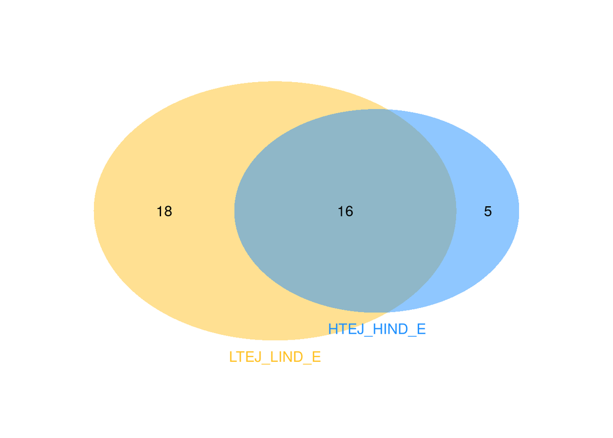

```r
HTEJ_HIND_E <- data[grepl("\\<HTEJ_HIND_E\\>",data[,2]),1]
LTEJ_LIND_E <- data[grepl("\\<LTEJ_LIND_E\\>",data[,2]),1]
color_v <- c("dodgerblue", "goldenrod1", "darkorange1", "seagreen3", "orchid3")[1:num]
p <- venn.diagram(
    x = list(HTEJ_HIND_E=HTEJ_HIND_E, LTEJ_LIND_E=LTEJ_LIND_E),
    filename = NULL, col = "transparent",
    fill = color_v,
    alpha = 0.50,
    label.col = c("black"),
    cex = 1, fontfamily = "Helvetica",
    cat.default.pos="outer",
    cat.pos=0, margin=0.1,
    cat.col = color_v,cat.cex = 1, cat.fontfamily = "Helvetica"
)
grid.draw(p)
```

Output common OTU in venn diagram

```bash
pwd
cat ../data/?IND-?TEJ_all.txt | grep 'Enriched' | cut -f 1 | sort | uniq -d > ../data/otu_IND_common_specific.txt
cat ../data/?IND-?TEJ_all.txt | grep 'Depleted' | cut -f 1 | sort | uniq -d > ../data/otu_TEJ_common_specific.txt
```

```
## /mnt/bai/yongxin/github/Zhang2019NBT/fig3
```

## f/h. Differentially abundance OTUs in time-course

e-g figure will draw after f-h, because the OTUs order determined by hierarchy cluster of time-course data.

(f, h) Pattern of relative abundance of the corresponding OTUs enriched in indica (f) or japonica (h) according to time-course data from the rice root microbiota in the field in Changping Farm. Columns represent the days of rice growth in the field.

Time-course data is from our previous published paper.

Cited: Zhang, J.Y., Zhang, N., Liu, Y.X., Zhang, X.N., Hu, B., Qin, Y., Xu, H.R., Wang, H., Guo, X.X., Qian, J.M., Wang, W., Zhang, P.F., Jin, T., Chu, C.C., and Bai, Y. (2018). Root microbiota shift in rice correlates with resident time in the field and developmental stage. Science China-Life Sciences 61, 613-621.

Github: https://github.com/microbiota/Zhang2018SCLS

### f. Indica specific OTUs in time-course

```r
design = read.table("../data/design.txt", header=T, row.names=1, sep="\t")
design$group = design$groupID
otutab = read.table(paste("../data/otutab.txt", sep=""), header=T, row.names=1, sep="\t", comment.char="")

# Select by manual set group，use Nippobare(A50)
if (TRUE){
  sub_design = subset(design, group %in% c("A50Cp1","A50Cp2","A50Cp3","A50Cp7","A50Cp10","A50Cp14","A50Cp21","A50Cp28","A50Cp35","A50Cp42","A50Cp49","A50Cp63","A50Cp70","A50Cp77","A50Cp84","A50Cp91","A50Cp98","A50Cp112","A50Cp119"))
  #  Set group order
  sub_design$group  = factor(sub_design$group, levels=c("A50Cp1","A50Cp2","A50Cp3","A50Cp7","A50Cp10","A50Cp14","A50Cp21","A50Cp28","A50Cp35","A50Cp42","A50Cp49","A50Cp63","A50Cp70","A50Cp77","A50Cp84","A50Cp91","A50Cp98","A50Cp112","A50Cp119"))
}
idx = rownames(sub_design) %in% colnames(otutab)
sub_design = sub_design[idx,]
sub_otutab = otutab[,rownames(sub_design)]
# head(sub_otutab)[,1:10]

# Normalize to read per million (RPM)
sub_norm =t(sub_otutab)/colSums(sub_otutab,na=T)*1000000
# head(sub_norm)[,1:10]
grp = sub_design[, "group", drop=F]
mat_t2 = merge(grp, sub_norm, by="row.names")
mat_t2 = mat_t2[,-1]
mat_mean = aggregate(mat_t2[,-1], by=mat_t2[1], FUN=mean) # mean
mat_mean_final = do.call(rbind, mat_mean)[-1,]
geno = mat_mean$group
colnames(mat_mean_final) = geno
dim(mat_mean_final)
```

```
## [1] 5141   19
```

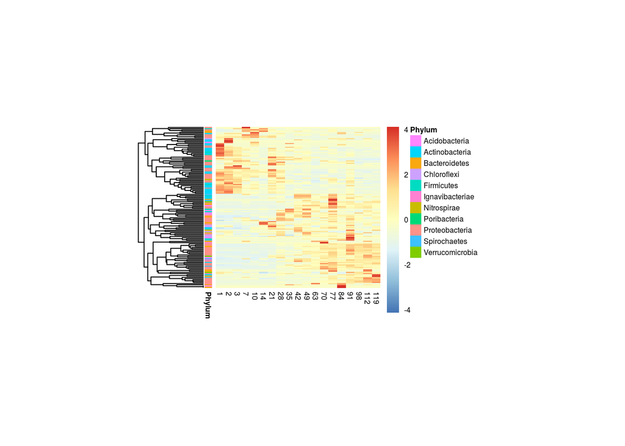

```r
mat_mean_final = as.data.frame(mat_mean_final)

#  filter OTUs in time-course
filtered = read.table("../data/otu_IND_common_specific.txt", header=F, sep="\t", comment.char="")
otutab.sub.mean = as.data.frame(mat_mean_final[as.vector(filtered$V1),])
no.abundance.in.timecourse = otutab.sub.mean[apply(otutab.sub.mean,1,max) < 0.0001, ]
otutab.sub.mean = otutab.sub.mean[apply(otutab.sub.mean,1,max) > 0.0001, ]
time = as.numeric(gsub("A50Cp", "", colnames(otutab.sub.mean)))
otu.time.cor = as.data.frame(cor(t(otutab.sub.mean), time))
otu.time.cor = otu.time.cor[order(otu.time.cor, decreasing = T),, drop=F]

tax = read.table("../data/taxonomy_8.txt", header=T, row.names =1, sep="\t", comment.char="")
anno_row = data.frame(Phylum = tax[rownames(otu.time.cor),]$Phylum, row.names = rownames(otu.time.cor))

# save plot for figure
pheatmap(mat_mean_final[rownames(mat_mean_final[rownames(otu.time.cor),]),], scale = "row", cluster_rows =T,    annotation_row = anno_row,
          cluster_cols = F, fontsize=6, cellwidth = 7, cellheight = 1,width=5, height=8,
         filename = paste("otu_IND_common_specific_time.pdf",sep=""),
         border_color = F, labels_col = gsub("A50Cp", "", colnames(mat_mean_final)), show_rownames = F)

pheatmap(mat_mean_final[rownames(mat_mean_final[rownames(otu.time.cor),]),], scale = "row", cluster_rows =T,    annotation_row = anno_row,
          cluster_cols = F, fontsize=6, cellwidth = 7, cellheight = 1,
         border_color = F, labels_col = gsub("A50Cp", "", colnames(mat_mean_final)), show_rownames = F)
```

```r
# save figure data
write.table(round(mat_mean_final[rownames(mat_mean_final[rownames(otu.time.cor),]),]/100,3), file = "otu_IND_common_specific_time.txt", sep = "\t", quote = F, row.names = T, col.names = T)
system("sed -i '1 s/^/OTUID\t/;s/A50Cp//g' otu_IND_common_specific_time.txt")

# save plot for supplement figure and label order
p = pheatmap(mat_mean_final[rownames(mat_mean_final[rownames(otu.time.cor),]),], scale = "row", cluster_rows =T,    annotation_row = anno_row,
         file = "otu_IND_common_specific_timeS.pdf",
        cellwidth = 7, cellheight = 4,  cluster_cols = F, fontsize=5, labels_col = gsub("A50Cp", "", colnames(mat_mean_final)))
# pheatmap object p, row lable in tree_row$lables, and order in tree_row$order
OTUID_new = p$tree_row$labels[p$tree_row$order]
# save OTU label new order after cluster
write.table(OTUID_new, file = "otu_IND_common_specific_time_clust.txt", sep = "\n", quote = F, row.names = F, col.names = F)
```

## h. Japonica specific OTUs in time-course

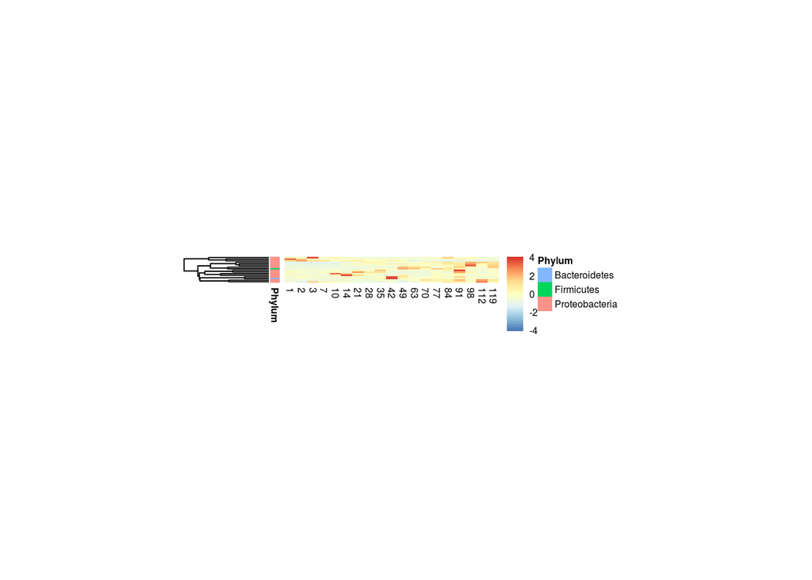

```r
filtered = read.table("../data/otu_TEJ_common_specific.txt", header=F, sep="\t", comment.char="")
otutab.sub.mean = as.data.frame(mat_mean_final[as.vector(filtered$V1),])
no.abundance.in.timecourse = otutab.sub.mean[apply(otutab.sub.mean,1,max) < 0.0001, ]
otutab.sub.mean = otutab.sub.mean[apply(otutab.sub.mean,1,max) > 0.0001, ]
time = as.numeric(gsub("A50Cp", "", colnames(otutab.sub.mean)))
otu.time.cor = as.data.frame(cor(t(otutab.sub.mean), time))
otu.time.cor = otu.time.cor[order(otu.time.cor, decreasing = T),, drop=F]

tax = read.table("../data/taxonomy_8.txt", header=T, row.names =1, sep="\t", comment.char="")
anno_row = data.frame(Phylum = tax[rownames(otu.time.cor),]$Phylum, row.names = rownames(otu.time.cor))


# save plot for figure
pheatmap(mat_mean_final[rownames(mat_mean_final[rownames(otu.time.cor),]),], scale = "row", cluster_rows =T,    annotation_row = anno_row,
          cluster_cols = F, fontsize=6, cellwidth = 7, cellheight = 1,width=5, height=8,
         filename = paste("otu_TEJ_common_specific_time.pdf",sep=""),
         border_color = F, labels_col = gsub("A50Cp", "", colnames(mat_mean_final)), show_rownames = F)

pheatmap(mat_mean_final[rownames(mat_mean_final[rownames(otu.time.cor),]),], scale = "row", cluster_rows =T,    annotation_row = anno_row,
          cluster_cols = F, fontsize=6, cellwidth = 7, cellheight = 1,
         border_color = F, labels_col = gsub("A50Cp", "", colnames(mat_mean_final)), show_rownames = F)
```

```r
# save figure data
write.table(round(mat_mean_final[rownames(mat_mean_final[rownames(otu.time.cor),]),]/100,3), file = "otu_TEJ_common_specific_time.txt", sep = "\t", quote = F, row.names = T, col.names = T)
system("sed -i '1 s/^/OTUID\t/;s/A50Cp//g' otu_TEJ_common_specific_time.txt")

# save plot for supplement figure and label order
p = pheatmap(mat_mean_final[rownames(mat_mean_final[rownames(otu.time.cor),]),], scale = "row", cluster_rows =T,    annotation_row = anno_row,
         file = "otu_TEJ_common_specific_timeS.pdf",
        cellwidth = 7, cellheight = 4,  cluster_cols = F, fontsize=5, labels_col = gsub("A50Cp", "", colnames(mat_mean_final)))
# pheatmap object p, row lable in tree_row$lables, and order in tree_row$order
OTUID_new = p$tree_row$labels[p$tree_row$order]
# save OTU label new order after cluster
write.table(OTUID_new, file = "otu_TEJ_common_specific_time_clust.txt", sep = "\n", quote = F, row.names = F, col.names = F)
```

## e/g. OTUs annotate by FAPROTAX

(e, g) Metabolic and ecological functions of OTUs enriched in indica (upper panel, e) and japonica (lower panel, g) in two fields based on FAPROTAX database. Each row represents an OTU. The presence of functions is shown in red.

### e. Indica enriched OTUs annotate by FAPROTAX

```r
high_cor = read.table("otu_IND_common_specific_time_clust.txt", header=F,  sep="\t", comment.char="", stringsAsFactors = F)
rownames(high_cor) = high_cor$V1
faprotax = read.table("../data/faprotax_report.mat", header=T, row.names=1, sep="\t", comment.char="")

x = merge(high_cor, faprotax, by="row.names", all.x=T)
x[is.na(x)] = 0

faprotax.sub =x
rownames(faprotax.sub) = faprotax.sub$Row.names
faprotax.sub = faprotax.sub[,-(1:2)]
faprotax.sub = faprotax.sub[high_cor$V1, ]
faprotax.sub = faprotax.sub[, colSums(faprotax.sub)>0]
faprotax_list_all = colnames(faprotax.sub)

# Manually select topic relation pathway
func_list = read.table("faprotax.id", header=F,  sep="\t", comment.char="", stringsAsFactors = F)
func_list$V1 %in% colnames(faprotax.sub)
```

```
##  [1] TRUE TRUE TRUE TRUE TRUE TRUE TRUE TRUE TRUE TRUE TRUE TRUE TRUE TRUE
## [15] TRUE TRUE TRUE
```

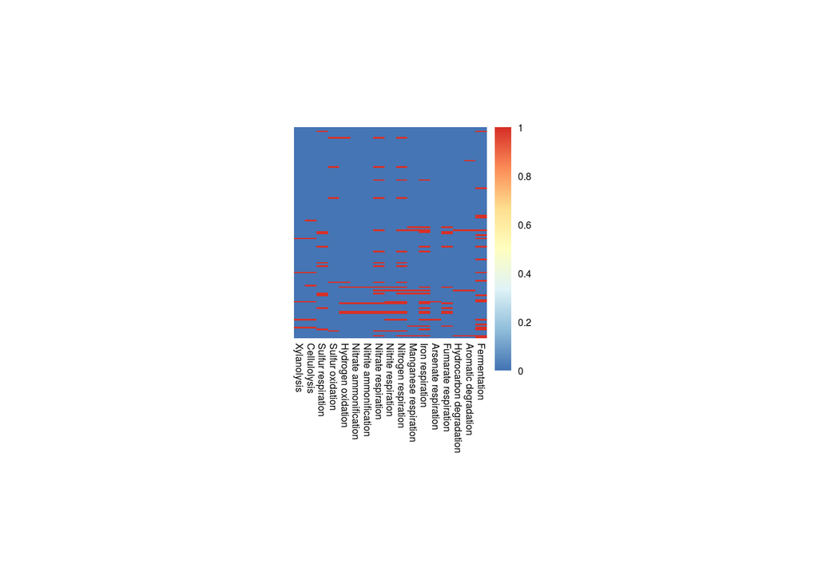

```r
faprotax.sub = faprotax.sub[,func_list$V1]

# Rename label: replace underline to space, uppercase firest alphabeta, and short some long name
faprotax_std = colnames(faprotax.sub)
faprotax_list = c("Xylanolysis","Cellulolysis","Sulfur respiration","Sulfur oxidation","Hydrogen oxidation","Nitrate ammonification","Nitrite ammonification","Nitrate respiration","Nitrite respiration","Nitrogen respiration","Manganese respiration","Iron respiration","Arsenate respiration","Fumarate respiration","Hydrocarbon degradation","Aromatic degradation","Fermentation")
colnames(faprotax.sub) = faprotax_list

pheatmap(faprotax.sub, cluster_rows = F, # filename = "../fig1/3compare/otu_IND_common_specific_time_faprotax3-30_2.pdf",
         cellwidth = 7, cellheight = 1,# annotation_row = anno_row,
         cluster_cols = F, fontsize=6, boder_color = F, show_rownames = F)
```

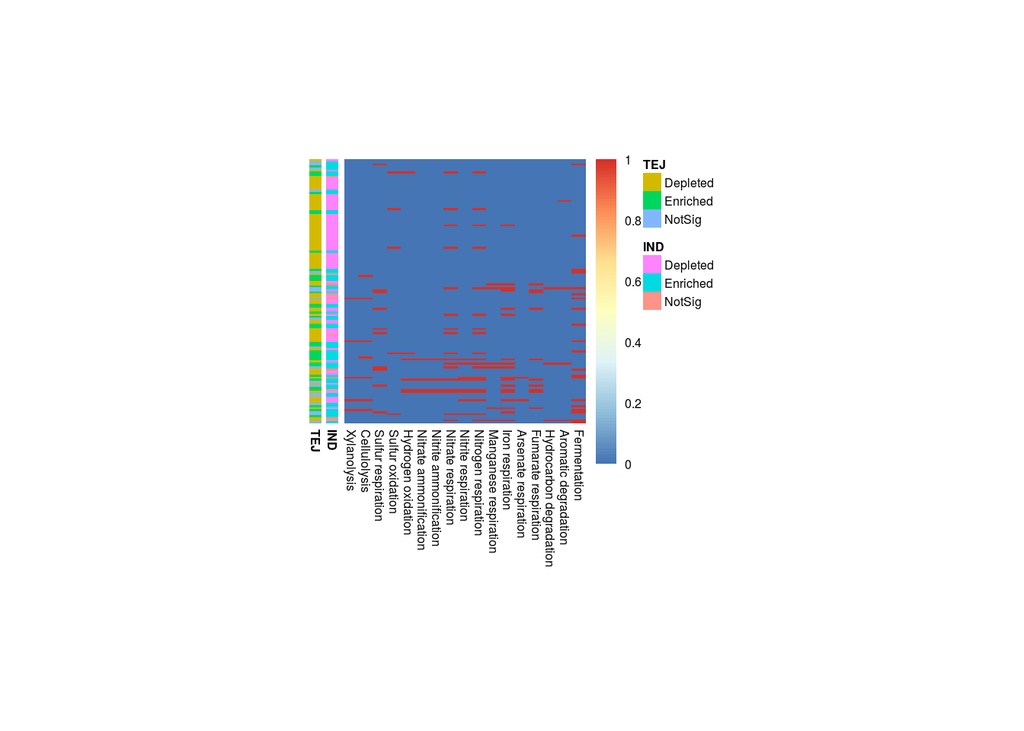

```r
# Save figure related table
write.table(faprotax.sub, file = "otu_IND_common_faprotax.txt", sep = "\t", quote = F, row.names = T, col.names = T)

# Add IND/TEJ vs Soil: Enriched/Depleted or NoSig
INDSoil = read.table("../data/IND-Soil_all.txt", header=T, row.names =1, sep="\t", comment.char="")
TEJSoil = read.table("../data/TEJ-Soil_all.txt", header=T, row.names =1, sep="\t", comment.char="")
anno_row = data.frame(IND = INDSoil[rownames(faprotax.sub),]$level, TEJ = TEJSoil[rownames(faprotax.sub),]$level, row.names = rownames(faprotax.sub))

pheatmap(faprotax.sub, cluster_rows = F, filename = "otu_IND_common_specific_time_faprotax.pdf",
         cellwidth = 7, cellheight = 1,annotation_row = anno_row,
         cluster_cols = F, fontsize=6, boder_color = F, show_rownames = F)

pheatmap(faprotax.sub, cluster_rows = F,
         cellwidth = 7, cellheight = 1,annotation_row = anno_row,
         cluster_cols = F, fontsize=6, boder_color = F, show_rownames = F)
```

### Indica specific OTUs enriched in nitrogen cycle

Permutation test is Indica specific OTUs significantlly enrichment in nitrogen-related pathway

```r
# Calculate 141 common OTU abundance, and frequence contatin 'nitr'
sample_OTU = read.table("../data/otu_IND_common_specific.txt", header=F, sep="\t", comment.char="")

faprotax = read.table("../data/faprotax_report.mat", header=T, row.names=1, sep="\t", comment.char="")
y=faprotax_std[grep('nitr', faprotax_std)]
count_anno = function(OTU_list){
x=OTU_list
rownames(x) = x$V1
m = merge(x, faprotax, by="row.names", all.x=T)
m[is.na(m)] = 0
rownames(m) = m$Row.names
m = m[,y]
N = sum(rowSums(m))
N
}
# 56 of 141 OTUs related to nitrogen metabolism
IND_count_anno = count_anno(sample_OTU)

# 1000 permutation test
OTU_all = read.table("../data/HIND-HTEJ_all.txt", header=T, row.names=NULL, sep="\t", comment.char="")

set.seed(1)
sample_OTU = as.data.frame(sample(OTU_all[,1],141))
colnames(sample_OTU)[1]="V1"
count_anno(sample_OTU)

n <- 1000
null <- vector("numeric",n)

# Ref: https://github.com/genomicsclass/labs/inference/random_variables.Rmd
for (i in 1:n) {
  set.seed(i)
  sample_OTU = as.data.frame(sample(OTU_all[,1],141))
  colnames(sample_OTU)[1]="V1"
  count_anno(sample_OTU)
  null[i] <- count_anno(sample_OTU)
}
histogram(null, freq=T)

pvalue = length(null[null>=IND_count_anno])/length(null)
pvalue

# ggplot plotting
df = as.data.frame(null)
colnames(df)="number"

p = ggplot(df, aes(x=number))+
  geom_line(stat="density", colour = "green")+
  geom_vline(xintercept=IND_count_anno, linetype=2)+
  annotate("text",x=IND_count_anno,y=0.03, label=paste("P = ", pvalue, sep="")) +
  theme_bw()
p
ggsave(paste("nitr_enriched_permutation.pdf", sep=""), p,
         width = 5, height = 3)

# 10 times, p = 0.1; 100 times, p = 0.02; 1000 times, p = 0.02.
```

[output not shown]

### Integrate FAPROTAX annotation and relative abundance

```r
# Total faprotax annotated 62.972%
# Sum heatmap to abundance
mean_abu = read.table(paste("../data/otu_mean_tax.txt",sep=""), header=T, row.names=1, sep="\t", comment.char="")
faprotax_indica = read.table(paste("otu_IND_common_faprotax.txt",sep=""), header=T, row.names=1, sep="\t", comment.char="")
mean_abu = mean_abu[rownames(faprotax_indica),c("Mean"), drop=F]
colSums(mean_abu)
```

```
##   Mean
## 27.297
```

```r
# Indica annotated total abundance is 27.297%

mean_abu2 = faprotax_indica * t(mean_abu)
mean_abu2_sum = colSums(mean_abu2)
write.table(mean_abu2_sum, file = "otu_IND_common_faprotax_RA.txt", quote = F, row.names = T, col.names = T, sep = "\t")
```

## g. Japonica specific OTUs in FAPROTAX

```r
high_cor = read.table("otu_TEJ_common_specific_time_clust.txt", header=F,  sep="\t", comment.char="", stringsAsFactors = F)
rownames(high_cor) = high_cor$V1
faprotax = read.table("../data/faprotax_report.mat", header=T, row.names=1, sep="\t", comment.char="")

x = merge(high_cor, faprotax, by="row.names", all.x=T)
x[is.na(x)] = 0
faprotax.sub =x
rownames(faprotax.sub) = faprotax.sub$Row.names
faprotax.sub = faprotax.sub[,-(1:2)]
faprotax.sub = faprotax.sub[high_cor$V1, func_list$V1]

# Rename label: replace underline to space, uppercase firest alphabeta, and short some long name
colnames(faprotax.sub)
```

```
##  [1] "xylanolysis"
##  [2] "cellulolysis"
##  [3] "respiration_of_sulfur_compounds"
##  [4] "dark_oxidation_of_sulfur_compounds"
##  [5] "dark_hydrogen_oxidation"
##  [6] "nitrate_ammonification"
##  [7] "nitrite_ammonification"
##  [8] "nitrate_respiration"
##  [9] "nitrite_respiration"
## [10] "nitrogen_respiration"
## [11] "manganese_respiration"
## [12] "iron_respiration"
## [13] "arsenate_respiration"
## [14] "fumarate_respiration"
## [15] "hydrocarbon_degradation"
## [16] "aromatic_compound_degradation"
## [17] "fermentation"
```

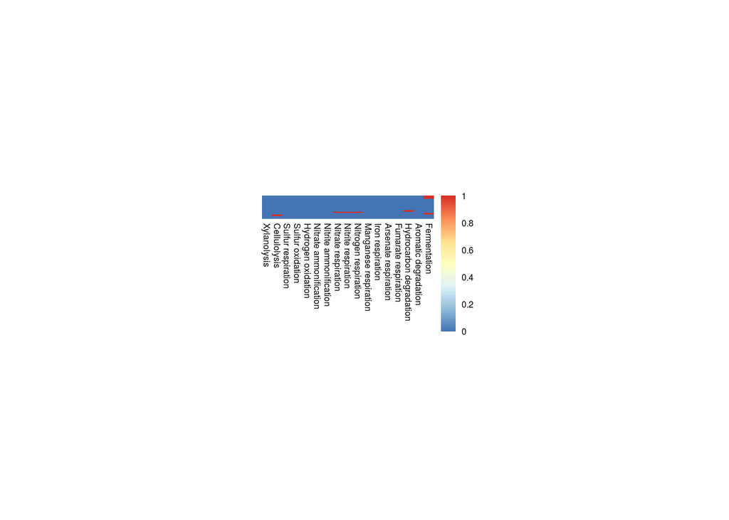

```r
colnames(faprotax.sub) = c("Xylanolysis","Cellulolysis","Sulfur respiration","Sulfur oxidation","Hydrogen oxidation","Nitrate ammonification","Nitrite ammonification","Nitrate respiration","Nitrite respiration","Nitrogen respiration","Manganese respiration","Iron respiration","Arsenate respiration","Fumarate respiration","Hydrocarbon degradation","Aromatic degradation","Fermentation")

pheatmap(faprotax.sub, cluster_rows = F, filename = "otu_TEJ_common_specific_time_faprotax.pdf",
         cellwidth = 7, cellheight = 1,
         cluster_cols = F, fontsize=6, boder_color = F, show_rownames = F)

pheatmap(faprotax.sub, cluster_rows = F, cellwidth = 7, cellheight = 1,
         cluster_cols = F, fontsize=6, boder_color = F, show_rownames = F)
```

```r
# Save figure related table
write.table(faprotax.sub, file = "otu_TEJ_common_faprotax.txt", sep = "\t", quote = F, row.names = T, col.names = T)
```

## I/J. Different function of indica or japonica

(i–j) Cumulative relative abundance of metabolic and ecological functions enriched in the root microbiota of indica (i) or japonica (j) varieties in two fields. The horizontal bars within boxes represent medians. The tops and bottoms of boxes represent 75th and 25th quartiles, respectively. The upper and lower whiskers extend 1.5 × the interquartile range from the upper edge and lower edge of the box, respectively. The number of biological replicates in this figure is as follows: in field I, indica (n = 201), japonica (n = 80); in field II, indica (n = 201), japonica (n = 81).

Script for Barplot

### i. indica enriched FAPROTAX pathway

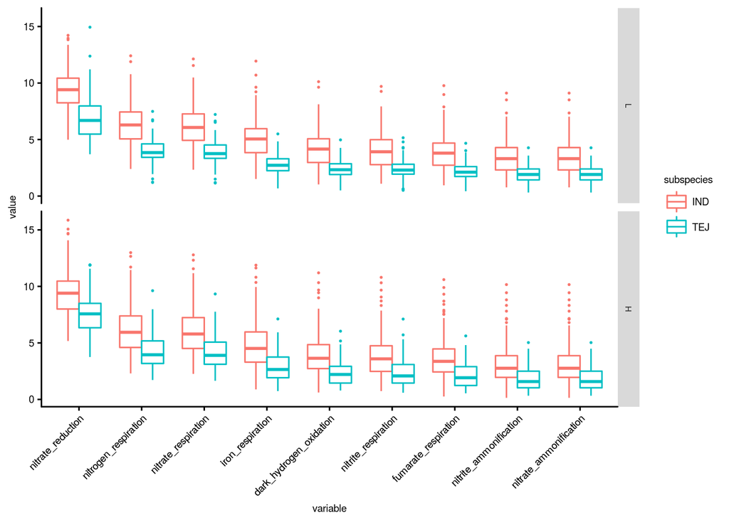

```r
# load or install related packages
site="https://mirrors.tuna.tsinghua.edu.cn/CRAN"
package_list = c("reshape2","ggplot2","devtools","bindrcpp",
                "ggthemes","agricolae","dplyr")
for(p in package_list){
    if(!suppressWarnings(suppressMessages(require(p, character.only = TRUE, quietly = TRUE, warn.conflicts = FALSE)))){
        install.packages(p, repos=site)
        suppressWarnings(suppressMessages(library(p, character.only = TRUE, quietly = TRUE, warn.conflicts = FALSE)))
  }
}

alpha = read.table("../data/element_tab.txt", header=T, row.names=1, sep="\t", comment.char="")
alpha = as.data.frame(t(alpha))
alpha=alpha/100
design = read.table("../data/design.txt", header=T, row.names=1, sep="\t")
design$group=design$groupID
sub_design = subset(design, group %in% c("HTEJ","HIND","LTEJ","LIND"))
sub_design$group  = factor(sub_design$group, levels=c("HTEJ","HIND","LTEJ","LIND"))
idx = rownames(sub_design) %in% rownames(alpha)
sub_design=sub_design[idx,]
# detach("package:ggpubr", unload=TRUE)
# library(dplyr)

list = read.table("IND.list", header=F,  sep="\t")
sub_alpha=alpha[rownames(sub_design), as.vector(list$V1)]
sub_alpha$sampleID=rownames(sub_alpha)
melted = melt(sub_alpha, id.vars = "sampleID")
melted_all = merge(melted, sub_design[,c("subspecies","soiltype")], by.x="sampleID", by.y = "row.names", all.x = T )
x = as.data.frame(melted_all %>% group_by(variable) %>%
  summarise(mean = mean(value)))
x = x[order(x$mean, decreasing = T),]
x = head(x, 9)
melted_all = melted_all[melted_all$variable %in% x$variable,]
melted_all$variable = factor(melted_all$variable, levels = as.vector(x$variable))
melted_all$soiltype = factor(melted_all$soiltype, levels=c("L", "H"))
p = ggplot(melted_all, aes(x=variable, y=value, color=subspecies)) +
  geom_boxplot(position = "dodge", alpha=1, outlier.size=0.3, size=0.5, width=0.7, fill="transparent") +
  main_theme +
  facet_grid(soiltype ~ .)+
  theme(axis.text.x=element_text(angle=45,vjust=1, hjust=1))
ggsave(paste("faprotax_IND_boxplot_top9", ".pdf", sep=""), p, width = 8, height = 5)
p
```

### j. japonica enriched FAPROTAX pathway

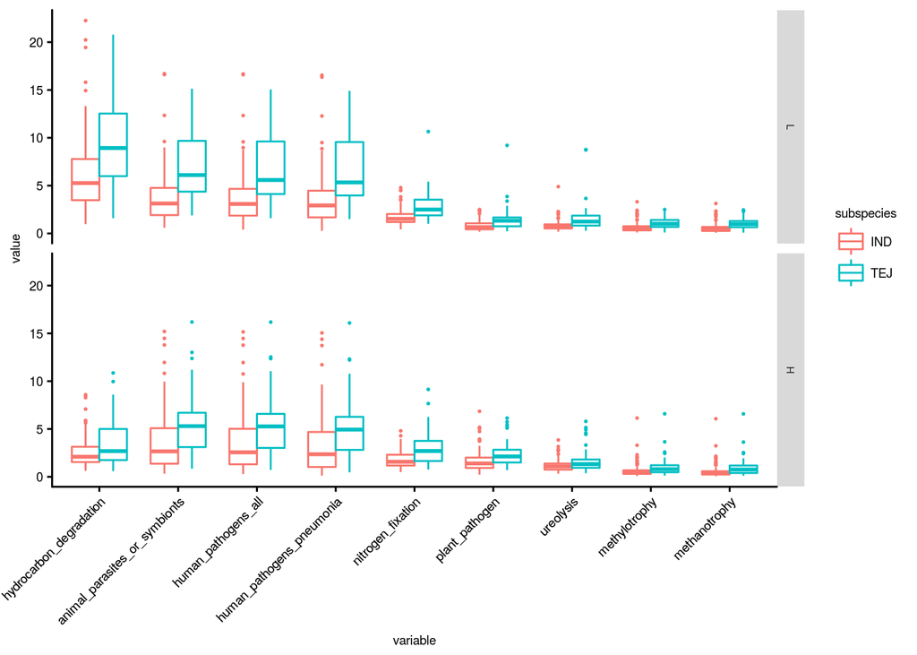

```r
list = read.table("TEJ.list", header=F,  sep="\t")
sub_alpha=alpha[rownames(sub_design), as.vector(list$V1)]
sub_alpha$sampleID=rownames(sub_alpha)
melted = melt(sub_alpha, id.vars = "sampleID")
melted_all = merge(melted, sub_design[,c("subspecies","soiltype")], by.x="sampleID", by.y = "row.names", all.x = T )
x = as.data.frame(melted_all %>% group_by(variable) %>%
  summarise(mean = mean(value)))
x = x[order(x$mean, decreasing = T),]
x = head(x, 9)
melted_all = melted_all[melted_all$variable %in% x$variable,]
melted_all$variable = factor(melted_all$variable, levels = as.vector(x$variable))
melted_all$soiltype = factor(melted_all$soiltype, levels=c("L", "H"))
p = ggplot(melted_all, aes(x=variable, y=value, color=subspecies)) +
  geom_boxplot(position = "dodge", alpha=1, outlier.size=0.3, size=0.5, width=0.7, fill="transparent") +
  main_theme +
  facet_grid(soiltype ~ .)+
  theme(axis.text.x=element_text(angle=45,vjust=1, hjust=1))
ggsave(paste("faprotax_TEJ_boxplot_top9", ".pdf", sep=""), p, width = 8, height = 5)
p
```